# Overview

Dataset info

| Number of variables | 16 |
| --- | --- |
| Number of observations | 767 |
| Total Missing (%) | 0.6% |
| Total size in memory | 96.0 KiB |
| Average record size in memory | 128.1 B |

Variables types

| Numeric | 12 |
| --- | --- |
| Categorical | 0 |
| Boolean | 0 |
| Date | 0 |
| Text (Unique) | 1 |
| Rejected | 3 |
| Unsupported | 0 |

Warnings

- `Aces` has 27 / 3.5% zeros Zeros
- `BreakPoints` has 20 / 2.6% zeros Zeros
- `BreakPoints_Won` has 52 / 6.8% zeros Zeros
- `DoubleFaults` has 19 / 2.5% zeros Zeros
- `FirstServes_In` is highly correlated with `FirstServes_Won` (ρ = 0.92271) Rejected
- `Rank` has 74 / 9.6% missing values Missing
- `ReturnPoints_Faced` is highly correlated with `ReturnPoints_Won` (ρ = 0.91953) Rejected
- `Sets_Won` has 141 / 18.4% zeros Zeros
- `TotalPoints_Won` is highly correlated with `ReturnPoints_Faced` (ρ = 0.94656) Rejected
- `won` has 219 / 28.6% zeros Zeros

# Variables

Aces  
Numeric

| Distinct count | 454 |
| --- | --- |
| Unique (%) | 59.2% |
| Missing (%) | 0.0% |
| Missing (n) | 0 |
| Infinite (%) | 0.0% |
| Infinite (n) | 0 |

| Mean | 4.5218 |
| --- | --- |
| Minimum | 0 |
| Maximum | 23 |
| Zeros (%) | 3.5% |

Toggle details

**Statistics**

Quantile statistics

| Minimum | 0 |
| --- | --- |
| 5-th percentile | 0.69167 |
| Q1 | 2.5 |
| Median | 4 |
| Q3 | 6 |
| 95-th percentile | 9.6336 |
| Maximum | 23 |
| Range | 23 |
| Interquartile range | 3.5 |

Descriptive statistics

| Standard deviation | 2.9432 |
| --- | --- |
| Coef of variation | 0.65089 |
| Kurtosis | 4.4671 |
| Mean | 4.5218 |
| MAD | 2.1883 |
| Skewness | 1.4697 |
| Sum | 3468.2 |
| Variance | 8.6622 |
| Memory size | 6.1 KiB |

**Histogram**

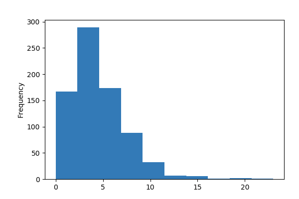

**Common Values**

| Value | Count | Frequency (%) |  |
| --- | --- | --- | --- |
| 2.0 | 38 | 5.0% |  |
| 1.0 | 35 | 4.6% |  |
| 4.0 | 34 | 4.4% |  |
| 3.0 | 33 | 4.3% |  |
| 0.0 | 27 | 3.5% |  |
| 5.0 | 19 | 2.5% |  |
| 6.0 | 11 | 1.4% |  |
| 2.5 | 10 | 1.3% |  |
| 8.0 | 8 | 1.0% |  |
| 4.333333333333333 | 7 | 0.9% |  |
| Other values (444) | 545 | 71.1% |  |

**Extreme Values**

Minimum 5 values

| Value | Count | Frequency (%) |  |
| --- | --- | --- | --- |
| 0.0 | 27 | 3.5% |  |
| 0.25 | 1 | 0.1% |  |
| 0.2857142857142857 | 1 | 0.1% |  |
| 0.3333333333333333 | 1 | 0.1% |  |
| 0.4 | 1 | 0.1% |  |

Maximum 5 values

| Value | Count | Frequency (%) |  |
| --- | --- | --- | --- |
| 15.310077519379846 | 1 | 0.1% |  |
| 17.347826086956523 | 1 | 0.1% |  |
| 19.062034739454095 | 1 | 0.1% |  |
| 20.088815789473685 | 1 | 0.1% |  |
| 23.0 | 1 | 0.1% |  |

BreakPoints  
Numeric

| Distinct count | 436 |
| --- | --- |
| Unique (%) | 56.8% |
| Missing (%) | 0.0% |
| Missing (n) | 0 |
| Infinite (%) | 0.0% |
| Infinite (n) | 0 |

| Mean | 5.6343 |
| --- | --- |
| Minimum | 0 |
| Maximum | 17 |
| Zeros (%) | 2.6% |

Toggle details

**Statistics**

Quantile statistics

| Minimum | 0 |
| --- | --- |
| 5-th percentile | 1 |
| Q1 | 4.6 |
| Median | 6 |
| Q3 | 7 |
| 95-th percentile | 8.6296 |
| Maximum | 17 |
| Range | 17 |
| Interquartile range | 2.4 |

Descriptive statistics

| Standard deviation | 2.2116 |
| --- | --- |
| Coef of variation | 0.39252 |
| Kurtosis | 1.618 |
| Mean | 5.6343 |
| MAD | 1.6579 |
| Skewness | -0.22028 |
| Sum | 4321.5 |
| Variance | 4.8912 |
| Memory size | 6.1 KiB |

**Histogram**

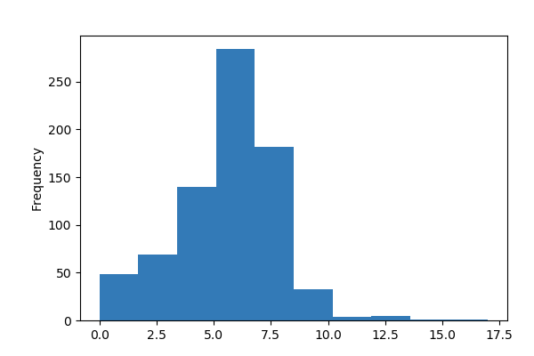

**Common Values**

| Value | Count | Frequency (%) |  |
| --- | --- | --- | --- |
| 5.0 | 30 | 3.9% |  |
| 4.0 | 27 | 3.5% |  |
| 2.0 | 24 | 3.1% |  |
| 3.0 | 23 | 3.0% |  |
| 6.0 | 21 | 2.7% |  |
| 7.0 | 20 | 2.6% |  |
| 0.0 | 20 | 2.6% |  |
| 1.0 | 19 | 2.5% |  |
| 8.0 | 9 | 1.2% |  |
| 7.5 | 9 | 1.2% |  |
| Other values (426) | 565 | 73.7% |  |

**Extreme Values**

Minimum 5 values

| Value | Count | Frequency (%) |  |
| --- | --- | --- | --- |
| 0.0 | 20 | 2.6% |  |
| 0.5 | 3 | 0.4% |  |
| 1.0 | 19 | 2.5% |  |
| 1.3333333333333333 | 1 | 0.1% |  |
| 1.5 | 3 | 0.4% |  |

Maximum 5 values

| Value | Count | Frequency (%) |  |
| --- | --- | --- | --- |
| 11.0 | 3 | 0.4% |  |
| 12.0 | 2 | 0.3% |  |
| 13.0 | 3 | 0.4% |  |
| 14.0 | 1 | 0.1% |  |
| 17.0 | 1 | 0.1% |  |

BreakPoints_Won  
Numeric

| Distinct count | 386 |
| --- | --- |
| Unique (%) | 50.3% |
| Missing (%) | 0.0% |
| Missing (n) | 0 |
| Infinite (%) | 0.0% |
| Infinite (n) | 0 |

| Mean | 2.1326 |
| --- | --- |
| Minimum | 0 |
| Maximum | 7 |
| Zeros (%) | 6.8% |

Toggle details

**Statistics**

Quantile statistics

| Minimum | 0 |
| --- | --- |
| 5-th percentile | 0 |
| Q1 | 1.6667 |
| Median | 2.2717 |
| Q3 | 2.7218 |
| 95-th percentile | 3.4702 |
| Maximum | 7 |
| Range | 7 |
| Interquartile range | 1.0551 |

Descriptive statistics

| Standard deviation | 0.96908 |
| --- | --- |
| Coef of variation | 0.45442 |
| Kurtosis | 0.90564 |
| Mean | 2.1326 |
| MAD | 0.74176 |
| Skewness | -0.26762 |
| Sum | 1635.7 |
| Variance | 0.93911 |
| Memory size | 6.1 KiB |

**Histogram**

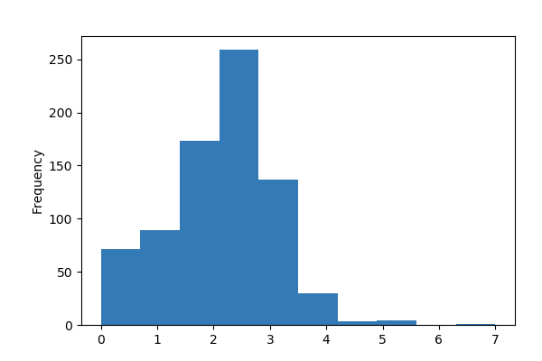

**Common Values**

| Value | Count | Frequency (%) |  |
| --- | --- | --- | --- |
| 2.0 | 62 | 8.1% |  |
| 1.0 | 60 | 7.8% |  |
| 0.0 | 52 | 6.8% |  |
| 3.0 | 30 | 3.9% |  |
| 2.5 | 18 | 2.3% |  |
| 2.3333333333333335 | 12 | 1.6% |  |
| 1.5 | 11 | 1.4% |  |
| 0.5 | 11 | 1.4% |  |
| 2.25 | 10 | 1.3% |  |
| 1.3333333333333333 | 9 | 1.2% |  |
| Other values (376) | 492 | 64.1% |  |

**Extreme Values**

Minimum 5 values

| Value | Count | Frequency (%) |  |
| --- | --- | --- | --- |
| 0.0 | 52 | 6.8% |  |
| 0.3333333333333333 | 2 | 0.3% |  |
| 0.4 | 1 | 0.1% |  |
| 0.5 | 11 | 1.4% |  |
| 0.625 | 1 | 0.1% |  |

Maximum 5 values

| Value | Count | Frequency (%) |  |
| --- | --- | --- | --- |
| 4.181818181818182 | 1 | 0.1% |  |
| 4.333333333333333 | 1 | 0.1% |  |
| 4.5 | 2 | 0.3% |  |
| 5.0 | 4 | 0.5% |  |
| 7.0 | 1 | 0.1% |  |

DoubleFaults  
Numeric

| Distinct count | 418 |
| --- | --- |
| Unique (%) | 54.5% |
| Missing (%) | 0.0% |
| Missing (n) | 0 |
| Infinite (%) | 0.0% |
| Infinite (n) | 0 |

| Mean | 3.1916 |
| --- | --- |
| Minimum | 0 |
| Maximum | 17 |
| Zeros (%) | 2.5% |

Toggle details

**Statistics**

Quantile statistics

| Minimum | 0 |
| --- | --- |
| 5-th percentile | 1 |
| Q1 | 2.273 |
| Median | 3 |
| Q3 | 3.8873 |
| 95-th percentile | 5.5 |
| Maximum | 17 |
| Range | 17 |
| Interquartile range | 1.6143 |

Descriptive statistics

| Standard deviation | 1.6523 |
| --- | --- |
| Coef of variation | 0.51771 |
| Kurtosis | 13.201 |
| Mean | 3.1916 |
| MAD | 1.0996 |
| Skewness | 2.3691 |
| Sum | 2448 |
| Variance | 2.7302 |
| Memory size | 6.1 KiB |

**Histogram**

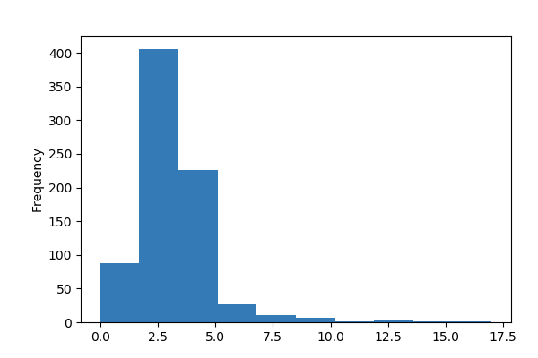

**Common Values**

| Value | Count | Frequency (%) |  |
| --- | --- | --- | --- |
| 3.0 | 53 | 6.9% |  |
| 2.0 | 48 | 6.3% |  |
| 4.0 | 29 | 3.8% |  |
| 1.0 | 27 | 3.5% |  |
| 5.0 | 26 | 3.4% |  |
| 0.0 | 19 | 2.5% |  |
| 2.5 | 17 | 2.2% |  |
| 1.5 | 10 | 1.3% |  |
| 3.5 | 7 | 0.9% |  |
| 3.6666666666666665 | 7 | 0.9% |  |
| Other values (408) | 524 | 68.3% |  |

**Extreme Values**

Minimum 5 values

| Value | Count | Frequency (%) |  |
| --- | --- | --- | --- |
| 0.0 | 19 | 2.5% |  |
| 0.6666666666666666 | 1 | 0.1% |  |
| 0.9090909090909091 | 1 | 0.1% |  |
| 1.0 | 27 | 3.5% |  |
| 1.25 | 2 | 0.3% |  |

Maximum 5 values

| Value | Count | Frequency (%) |  |
| --- | --- | --- | --- |
| 11.333333333333334 | 1 | 0.1% |  |
| 12.0 | 1 | 0.1% |  |
| 12.5 | 1 | 0.1% |  |
| 15.0 | 1 | 0.1% |  |
| 17.0 | 1 | 0.1% |  |

FirstServes_In  
Highly correlated

*This variable is highly correlated with `FirstServes_Won` and should be ignored for analysis*

| Correlation | 0.92271 |
| --- | --- |

FirstServes_Won  
Numeric

| Distinct count | 529 |
| --- | --- |
| Unique (%) | 69.0% |
| Missing (%) | 0.0% |
| Missing (n) | 0 |
| Infinite (%) | 0.0% |
| Infinite (n) | 0 |

| Mean | 30.442 |
| --- | --- |
| Minimum | 1 |
| Maximum | 62 |
| Zeros (%) | 0.0% |

Toggle details

**Statistics**

Quantile statistics

| Minimum | 1 |
| --- | --- |
| 5-th percentile | 16 |
| Q1 | 27 |
| Median | 31.545 |
| Q3 | 34.748 |
| 95-th percentile | 39.793 |
| Maximum | 62 |
| Range | 61 |
| Interquartile range | 7.7476 |

Descriptive statistics

| Standard deviation | 7.3162 |
| --- | --- |
| Coef of variation | 0.24033 |
| Kurtosis | 1.9122 |
| Mean | 30.442 |
| MAD | 5.3898 |
| Skewness | -0.48846 |
| Sum | 23349 |
| Variance | 53.527 |
| Memory size | 6.1 KiB |

**Histogram**

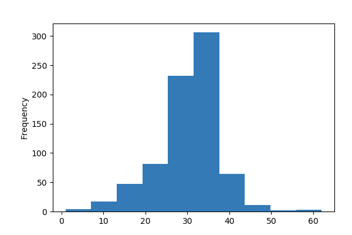

**Common Values**

| Value | Count | Frequency (%) |  |
| --- | --- | --- | --- |
| 25.0 | 13 | 1.7% |  |
| 26.0 | 13 | 1.7% |  |
| 27.0 | 12 | 1.6% |  |
| 18.0 | 10 | 1.3% |  |
| 28.0 | 9 | 1.2% |  |
| 24.0 | 9 | 1.2% |  |
| 34.0 | 9 | 1.2% |  |
| 31.0 | 8 | 1.0% |  |
| 29.0 | 8 | 1.0% |  |
| 21.0 | 8 | 1.0% |  |
| Other values (519) | 668 | 87.1% |  |

**Extreme Values**

Minimum 5 values

| Value | Count | Frequency (%) |  |
| --- | --- | --- | --- |
| 1.0 | 1 | 0.1% |  |
| 6.5 | 1 | 0.1% |  |
| 7.0 | 2 | 0.3% |  |
| 7.333333333333333 | 1 | 0.1% |  |
| 9.0 | 1 | 0.1% |  |

Maximum 5 values

| Value | Count | Frequency (%) |  |
| --- | --- | --- | --- |
| 51.0 | 1 | 0.1% |  |
| 52.0 | 1 | 0.1% |  |
| 58.5 | 1 | 0.1% |  |
| 61.5 | 1 | 0.1% |  |
| 62.0 | 1 | 0.1% |  |

Games_Won  
Numeric

| Distinct count | 460 |
| --- | --- |
| Unique (%) | 60.0% |
| Missing (%) | 0.0% |
| Missing (n) | 0 |
| Infinite (%) | 0.0% |
| Infinite (n) | 0 |

| Mean | 10.34 |
| --- | --- |
| Minimum | 0 |
| Maximum | 18 |
| Zeros (%) | 0.1% |

Toggle details

**Statistics**

Quantile statistics

| Minimum | 0 |
| --- | --- |
| 5-th percentile | 4 |
| Q1 | 9 |
| Median | 11.1 |
| Q3 | 12.333 |
| 95-th percentile | 13.889 |
| Maximum | 18 |
| Range | 18 |
| Interquartile range | 3.3333 |

Descriptive statistics

| Standard deviation | 2.9324 |
| --- | --- |
| Coef of variation | 0.28359 |
| Kurtosis | 0.71394 |
| Mean | 10.34 |
| MAD | 2.2882 |
| Skewness | -0.97551 |
| Sum | 7931 |
| Variance | 8.599 |
| Memory size | 6.1 KiB |

**Histogram**

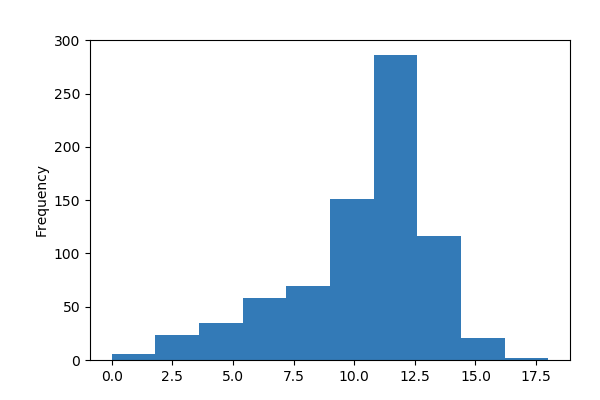

**Common Values**

| Value | Count | Frequency (%) |  |
| --- | --- | --- | --- |
| 7.0 | 25 | 3.3% |  |
| 10.0 | 23 | 3.0% |  |
| 6.0 | 22 | 2.9% |  |
| 8.0 | 19 | 2.5% |  |
| 5.0 | 18 | 2.3% |  |
| 3.0 | 17 | 2.2% |  |
| 9.0 | 16 | 2.1% |  |
| 12.0 | 14 | 1.8% |  |
| 4.0 | 13 | 1.7% |  |
| 11.0 | 11 | 1.4% |  |
| Other values (450) | 589 | 76.8% |  |

**Extreme Values**

Minimum 5 values

| Value | Count | Frequency (%) |  |
| --- | --- | --- | --- |
| 0.0 | 1 | 0.1% |  |
| 0.6666666666666666 | 1 | 0.1% |  |
| 1.0 | 2 | 0.3% |  |
| 1.5 | 2 | 0.3% |  |
| 2.0 | 5 | 0.7% |  |

Maximum 5 values

| Value | Count | Frequency (%) |  |
| --- | --- | --- | --- |
| 15.254201680672269 | 1 | 0.1% |  |
| 15.325358851674642 | 1 | 0.1% |  |
| 16.0 | 4 | 0.5% |  |
| 17.0 | 1 | 0.1% |  |
| 18.0 | 1 | 0.1% |  |

Player  
Categorical, Unique

| First 3 values |
| --- |
| Tigre Hank |
| Alessandro Giannessi |
| Kenny De Schepper |

| Last 3 values |
| --- |
| Mousa Shanan Zayed |
| Jacob Grills |
| Stefano Napolitano |

Toggle details

First 10 values

| Value | Count | Frequency (%) |  |
| --- | --- | --- | --- |
| Adam Feeney | 1 | 0.1% |  |
| Adam Pavlasek | 1 | 0.1% |  |
| Adrian Andreev | 1 | 0.1% |  |
| Adrian Mannarino | 1 | 0.1% |  |
| Adrian Menendez-Maceiras | 1 | 0.1% |  |

Last 10 values

| Value | Count | Frequency (%) |  |
| --- | --- | --- | --- |
| Yusuke Takahashi | 1 | 0.1% |  |
| Zbynek Mlynarik | 1 | 0.1% |  |
| Ze Zhang | 1 | 0.1% |  |
| Zhe Li | 1 | 0.1% |  |
| Zhizhen Zhang | 1 | 0.1% |  |

Rank  
Numeric

| Distinct count | 659 |
| --- | --- |
| Unique (%) | 85.9% |
| Missing (%) | 9.6% |
| Missing (n) | 74 |
| Infinite (%) | 0.0% |
| Infinite (n) | 0 |

| Mean | 212.42 |
| --- | --- |
| Minimum | 2.7983 |
| Maximum | 599 |
| Zeros (%) | 0.0% |

Toggle details

**Statistics**

Quantile statistics

| Minimum | 2.7983 |
| --- | --- |
| 5-th percentile | 44.245 |
| Q1 | 119.18 |
| Median | 209.23 |
| Q3 | 268 |
| 95-th percentile | 459.6 |
| Maximum | 599 |
| Range | 596.2 |
| Interquartile range | 148.82 |

Descriptive statistics

| Standard deviation | 122.14 |
| --- | --- |
| Coef of variation | 0.575 |
| Kurtosis | 0.33749 |
| Mean | 212.42 |
| MAD | 94.269 |
| Skewness | 0.73353 |
| Sum | 147210 |
| Variance | 14919 |
| Memory size | 6.1 KiB |

**Histogram**

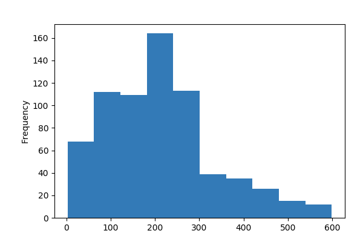

**Common Values**

| Value | Count | Frequency (%) |  |
| --- | --- | --- | --- |
| 340.0 | 4 | 0.5% |  |
| 544.0 | 3 | 0.4% |  |
| 281.0 | 3 | 0.4% |  |
| 280.0 | 3 | 0.4% |  |
| 327.0 | 2 | 0.3% |  |
| 229.0 | 2 | 0.3% |  |
| 222.0 | 2 | 0.3% |  |
| 393.0 | 2 | 0.3% |  |
| 284.0 | 2 | 0.3% |  |
| 255.0 | 2 | 0.3% |  |
| Other values (648) | 668 | 87.1% |  |
| (Missing) | 74 | 9.6% |  |

**Extreme Values**

Minimum 5 values

| Value | Count | Frequency (%) |  |
| --- | --- | --- | --- |
| 2.7983193277310923 | 1 | 0.1% |  |
| 3.3995215311004783 | 1 | 0.1% |  |
| 3.633257403189066 | 1 | 0.1% |  |
| 8.065882352941177 | 1 | 0.1% |  |
| 10.122762148337596 | 1 | 0.1% |  |

Maximum 5 values

| Value | Count | Frequency (%) |  |
| --- | --- | --- | --- |
| 557.0 | 1 | 0.1% |  |
| 563.0 | 1 | 0.1% |  |
| 572.0 | 1 | 0.1% |  |
| 589.0 | 1 | 0.1% |  |
| 599.0 | 1 | 0.1% |  |

ReturnPoints_Faced  
Highly correlated

*This variable is highly correlated with `ReturnPoints_Won` and should be ignored for analysis*

| Correlation | 0.91953 |
| --- | --- |

ReturnPoints_Won  
Numeric

| Distinct count | 520 |
| --- | --- |
| Unique (%) | 67.8% |
| Missing (%) | 0.1% |
| Missing (n) | 1 |
| Infinite (%) | 0.0% |
| Infinite (n) | 0 |

| Mean | 25.322 |
| --- | --- |
| Minimum | 0 |
| Maximum | 53 |
| Zeros (%) | 0.1% |

Toggle details

**Statistics**

Quantile statistics

| Minimum | 0 |
| --- | --- |
| 5-th percentile | 12 |
| Q1 | 22.083 |
| Median | 26.819 |
| Q3 | 29.34 |
| 95-th percentile | 33.24 |
| Maximum | 53 |
| Range | 53 |
| Interquartile range | 7.2562 |

Descriptive statistics

| Standard deviation | 6.5152 |
| --- | --- |
| Coef of variation | 0.25729 |
| Kurtosis | 1.3894 |
| Mean | 25.322 |
| MAD | 4.9404 |
| Skewness | -0.63855 |
| Sum | 19397 |
| Variance | 42.448 |
| Memory size | 6.1 KiB |

**Histogram**

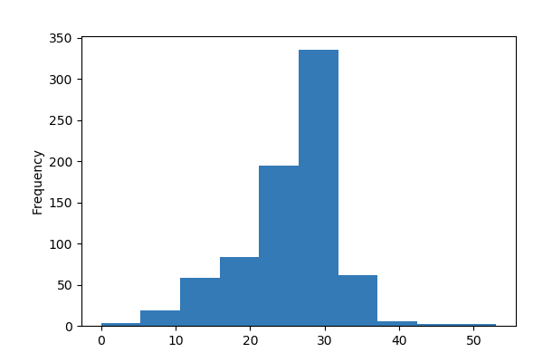

**Common Values**

| Value | Count | Frequency (%) |  |
| --- | --- | --- | --- |
| 12.0 | 12 | 1.6% |  |
| 24.0 | 12 | 1.6% |  |
| 27.0 | 11 | 1.4% |  |
| 20.0 | 11 | 1.4% |  |
| 22.0 | 11 | 1.4% |  |
| 15.0 | 10 | 1.3% |  |
| 32.0 | 9 | 1.2% |  |
| 25.0 | 9 | 1.2% |  |
| 26.0 | 9 | 1.2% |  |
| 11.0 | 8 | 1.0% |  |
| Other values (509) | 664 | 86.6% |  |

**Extreme Values**

Minimum 5 values

| Value | Count | Frequency (%) |  |
| --- | --- | --- | --- |
| 0.0 | 1 | 0.1% |  |
| 2.0 | 1 | 0.1% |  |
| 5.0 | 1 | 0.1% |  |
| 6.0 | 2 | 0.3% |  |
| 7.5 | 1 | 0.1% |  |

Maximum 5 values

| Value | Count | Frequency (%) |  |
| --- | --- | --- | --- |
| 42.0 | 2 | 0.3% |  |
| 44.0 | 1 | 0.1% |  |
| 45.0 | 1 | 0.1% |  |
| 51.0 | 1 | 0.1% |  |
| 53.0 | 1 | 0.1% |  |

SecondServes_In  
Numeric

| Distinct count | 526 |
| --- | --- |
| Unique (%) | 68.6% |
| Missing (%) | 0.0% |
| Missing (n) | 0 |
| Infinite (%) | 0.0% |
| Infinite (n) | 0 |

| Mean | 29.64 |
| --- | --- |
| Minimum | 1 |
| Maximum | 74 |
| Zeros (%) | 0.0% |

Toggle details

**Statistics**

Quantile statistics

| Minimum | 1 |
| --- | --- |
| 5-th percentile | 19 |
| Q1 | 26.333 |
| Median | 29.976 |
| Q3 | 33 |
| 95-th percentile | 39.85 |
| Maximum | 74 |
| Range | 73 |
| Interquartile range | 6.6667 |

Descriptive statistics

| Standard deviation | 6.4525 |
| --- | --- |
| Coef of variation | 0.21769 |
| Kurtosis | 4.2089 |
| Mean | 29.64 |
| MAD | 4.6576 |
| Skewness | 0.33924 |
| Sum | 22734 |
| Variance | 41.635 |
| Memory size | 6.1 KiB |

**Histogram**

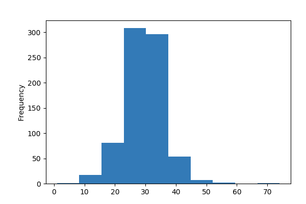

**Common Values**

| Value | Count | Frequency (%) |  |
| --- | --- | --- | --- |
| 27.0 | 15 | 2.0% |  |
| 28.0 | 15 | 2.0% |  |
| 22.0 | 14 | 1.8% |  |
| 30.0 | 14 | 1.8% |  |
| 21.0 | 13 | 1.7% |  |
| 25.0 | 12 | 1.6% |  |
| 26.0 | 11 | 1.4% |  |
| 29.0 | 11 | 1.4% |  |
| 31.0 | 9 | 1.2% |  |
| 33.0 | 8 | 1.0% |  |
| Other values (516) | 645 | 84.1% |  |

**Extreme Values**

Minimum 5 values

| Value | Count | Frequency (%) |  |
| --- | --- | --- | --- |
| 1.0 | 1 | 0.1% |  |
| 9.0 | 2 | 0.3% |  |
| 9.5 | 1 | 0.1% |  |
| 10.666666666666666 | 1 | 0.1% |  |
| 11.0 | 1 | 0.1% |  |

Maximum 5 values

| Value | Count | Frequency (%) |  |
| --- | --- | --- | --- |
| 50.0 | 1 | 0.1% |  |
| 51.0 | 1 | 0.1% |  |
| 52.0 | 1 | 0.1% |  |
| 54.0 | 2 | 0.3% |  |
| 74.0 | 1 | 0.1% |  |

SecondServes_Won  
Numeric

| Distinct count | 477 |
| --- | --- |
| Unique (%) | 62.2% |
| Missing (%) | 0.0% |
| Missing (n) | 0 |
| Infinite (%) | 0.0% |
| Infinite (n) | 0 |

| Mean | 14.09 |
| --- | --- |
| Minimum | 0.5 |
| Maximum | 33 |
| Zeros (%) | 0.0% |

Toggle details

**Statistics**

Quantile statistics

| Minimum | 0.5 |
| --- | --- |
| 5-th percentile | 7 |
| Q1 | 12 |
| Median | 14.507 |
| Q3 | 16.333 |
| 95-th percentile | 19.444 |
| Maximum | 33 |
| Range | 32.5 |
| Interquartile range | 4.3333 |

Descriptive statistics

| Standard deviation | 3.7712 |
| --- | --- |
| Coef of variation | 0.26765 |
| Kurtosis | 1.7871 |
| Mean | 14.09 |
| MAD | 2.8047 |
| Skewness | -0.41903 |
| Sum | 10807 |
| Variance | 14.222 |
| Memory size | 6.1 KiB |

**Histogram**

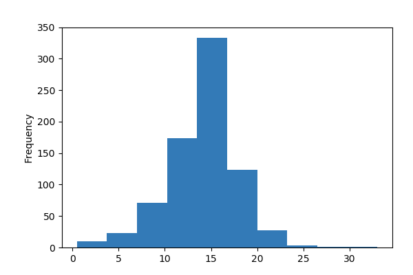

**Common Values**

| Value | Count | Frequency (%) |  |
| --- | --- | --- | --- |
| 12.0 | 23 | 3.0% |  |
| 11.0 | 23 | 3.0% |  |
| 13.0 | 21 | 2.7% |  |
| 15.0 | 18 | 2.3% |  |
| 10.0 | 13 | 1.7% |  |
| 7.0 | 13 | 1.7% |  |
| 14.0 | 13 | 1.7% |  |
| 8.0 | 11 | 1.4% |  |
| 16.0 | 11 | 1.4% |  |
| 18.0 | 11 | 1.4% |  |
| Other values (467) | 610 | 79.5% |  |

**Extreme Values**

Minimum 5 values

| Value | Count | Frequency (%) |  |
| --- | --- | --- | --- |
| 0.5 | 1 | 0.1% |  |
| 1.0 | 3 | 0.4% |  |
| 3.0 | 5 | 0.7% |  |
| 3.3333333333333335 | 1 | 0.1% |  |
| 4.0 | 2 | 0.3% |  |

Maximum 5 values

| Value | Count | Frequency (%) |  |
| --- | --- | --- | --- |
| 23.0 | 2 | 0.3% |  |
| 24.0 | 2 | 0.3% |  |
| 25.0 | 1 | 0.1% |  |
| 27.0 | 1 | 0.1% |  |
| 33.0 | 1 | 0.1% |  |

Sets_Won  
Numeric

| Distinct count | 332 |
| --- | --- |
| Unique (%) | 43.3% |
| Missing (%) | 0.0% |
| Missing (n) | 0 |
| Infinite (%) | 0.0% |
| Infinite (n) | 0 |

| Mean | 0.82984 |
| --- | --- |
| Minimum | 0 |
| Maximum | 2.1113 |
| Zeros (%) | 18.4% |

Toggle details

**Statistics**

Quantile statistics

| Minimum | 0 |
| --- | --- |
| 5-th percentile | 0 |
| Q1 | 0.5 |
| Median | 1 |
| Q3 | 1.1589 |
| 95-th percentile | 1.4556 |
| Maximum | 2.1113 |
| Range | 2.1113 |
| Interquartile range | 0.6589 |

Descriptive statistics

| Standard deviation | 0.48314 |
| --- | --- |
| Coef of variation | 0.5822 |
| Kurtosis | -0.63677 |
| Mean | 0.82984 |
| MAD | 0.39786 |
| Skewness | -0.52555 |
| Sum | 636.49 |
| Variance | 0.23342 |
| Memory size | 6.1 KiB |

**Histogram**

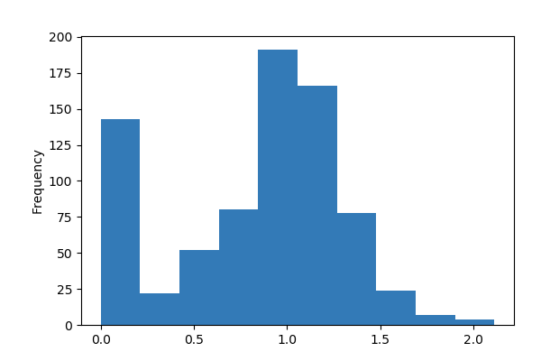

**Common Values**

| Value | Count | Frequency (%) |  |
| --- | --- | --- | --- |
| 0.0 | 141 | 18.4% |  |
| 1.0 | 100 | 13.0% |  |
| 0.5 | 28 | 3.7% |  |
| 0.6666666666666666 | 21 | 2.7% |  |
| 0.8 | 14 | 1.8% |  |
| 0.3333333333333333 | 10 | 1.3% |  |
| 1.25 | 8 | 1.0% |  |
| 0.6 | 8 | 1.0% |  |
| 1.5 | 7 | 0.9% |  |
| 1.3333333333333333 | 7 | 0.9% |  |
| Other values (322) | 423 | 55.1% |  |

**Extreme Values**

Minimum 5 values

| Value | Count | Frequency (%) |  |
| --- | --- | --- | --- |
| 0.0 | 141 | 18.4% |  |
| 0.2 | 2 | 0.3% |  |
| 0.25 | 7 | 0.9% |  |
| 0.3333333333333333 | 10 | 1.3% |  |
| 0.36363636363636365 | 1 | 0.1% |  |

Maximum 5 values

| Value | Count | Frequency (%) |  |
| --- | --- | --- | --- |
| 1.7774193548387096 | 1 | 0.1% |  |
| 1.9931662870159452 | 1 | 0.1% |  |
| 2.017766497461929 | 1 | 0.1% |  |
| 2.0382775119617227 | 1 | 0.1% |  |
| 2.111344537815126 | 1 | 0.1% |  |

TotalPoints_Won  
Highly correlated

*This variable is highly correlated with `ReturnPoints_Faced` and should be ignored for analysis*

| Correlation | 0.94656 |
| --- | --- |

won  
Numeric

| Distinct count | 285 |
| --- | --- |
| Unique (%) | 37.2% |
| Missing (%) | 0.0% |
| Missing (n) | 0 |
| Infinite (%) | 0.0% |
| Infinite (n) | 0 |

| Mean | 0.2892 |
| --- | --- |
| Minimum | 0 |
| Maximum | 0.86975 |
| Zeros (%) | 28.6% |

Toggle details

**Statistics**

Quantile statistics

| Minimum | 0 |
| --- | --- |
| 5-th percentile | 0 |
| Q1 | 0 |
| Median | 0.33333 |
| Q3 | 0.44799 |
| 95-th percentile | 0.57577 |
| Maximum | 0.86975 |
| Range | 0.86975 |
| Interquartile range | 0.44799 |

Descriptive statistics

| Standard deviation | 0.21181 |
| --- | --- |
| Coef of variation | 0.73242 |
| Kurtosis | -1.1174 |
| Mean | 0.2892 |
| MAD | 0.1838 |
| Skewness | -0.17072 |
| Sum | 221.82 |
| Variance | 0.044865 |
| Memory size | 6.1 KiB |

**Histogram**

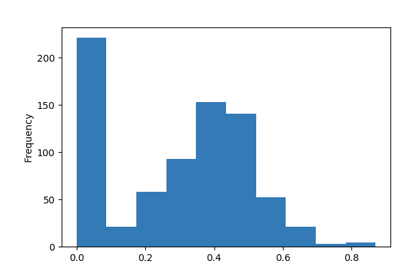

**Common Values**

| Value | Count | Frequency (%) |  |
| --- | --- | --- | --- |
| 0.0 | 219 | 28.6% |  |
| 0.3333333333333333 | 43 | 5.6% |  |
| 0.5 | 39 | 5.1% |  |
| 0.25 | 24 | 3.1% |  |
| 0.4 | 19 | 2.5% |  |
| 0.2 | 16 | 2.1% |  |
| 0.375 | 11 | 1.4% |  |
| 0.42857142857142855 | 11 | 1.4% |  |
| 0.16666666666666666 | 10 | 1.3% |  |
| 0.4444444444444444 | 9 | 1.2% |  |
| Other values (275) | 366 | 47.7% |  |

**Extreme Values**

Minimum 5 values

| Value | Count | Frequency (%) |  |
| --- | --- | --- | --- |
| 0.0 | 219 | 28.6% |  |
| 0.07142857142857142 | 1 | 0.1% |  |
| 0.08333333333333333 | 1 | 0.1% |  |
| 0.1 | 1 | 0.1% |  |
| 0.125 | 2 | 0.3% |  |

Maximum 5 values

| Value | Count | Frequency (%) |  |
| --- | --- | --- | --- |
| 0.7516129032258064 | 1 | 0.1% |  |
| 0.8096446700507615 | 1 | 0.1% |  |
| 0.8373205741626795 | 1 | 0.1% |  |
| 0.8382687927107062 | 1 | 0.1% |  |
| 0.8697478991596639 | 1 | 0.1% |  |

# Correlations

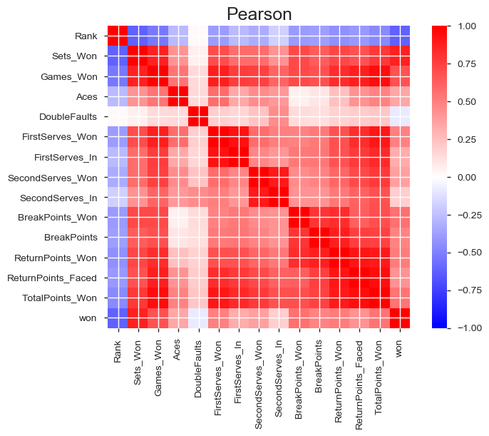

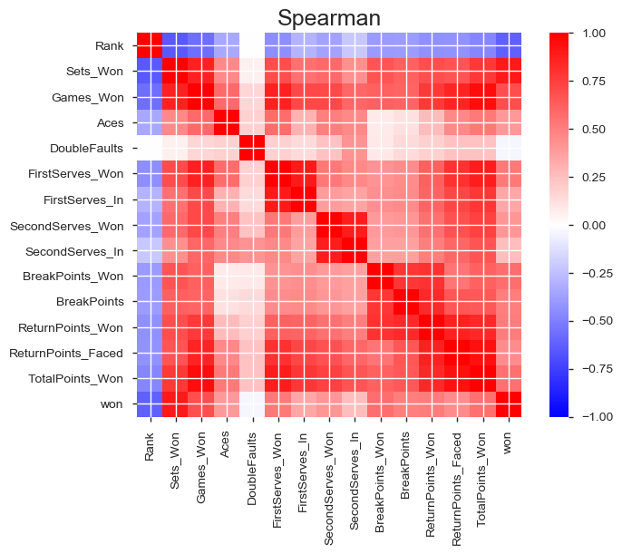

# Sample

| Player | Rank | Sets_Won | Games_Won | Aces | DoubleFaults | FirstServes_Won | FirstServes_In | SecondServes_Won | SecondServes_In | BreakPoints_Won | BreakPoints | ReturnPoints_Won | ReturnPoints_Faced | TotalPoints_Won | won |
| --- | --- | --- | --- | --- | --- | --- | --- | --- | --- | --- | --- | --- | --- | --- | --- |
| Adam Feeney | 327.000000 | 1.000000 | 13.000000 | 0.500000 | 5.000000 | 37.500000 | 58.500000 | 13.000000 | 28.500000 | 3.500000 | 13.000000 | 38.500000 | 95.000000 | 89.000000 | 0.500000 |
| Adam Pavlasek | 146.464286 | 1.250000 | 11.892857 | 6.607143 | 2.750000 | 35.214286 | 50.678571 | 15.678571 | 32.535714 | 2.821429 | 6.214286 | 28.640000 | 78.120000 | 80.000000 | 0.428571 |
| Adrian Andreev | NaN | 0.000000 | 7.000000 | 1.000000 | 3.000000 | 18.000000 | 39.000000 | 10.000000 | 19.000000 | 3.000000 | 4.000000 | 20.000000 | 56.000000 | 48.000000 | 0.000000 |
| Adrian Mannarino | 55.681063 | 1.230000 | 12.245847 | 4.667774 | 2.634551 | 32.820598 | 47.275748 | 15.382060 | 30.189369 | 2.816667 | 6.660000 | 28.459732 | 76.932886 | 76.943522 | 0.471761 |
| Adrian Menendez-Maceiras | 162.453125 | 1.109375 | 11.765625 | 4.531250 | 2.000000 | 33.140625 | 48.515625 | 15.562500 | 29.921875 | 2.343750 | 5.890625 | 27.379310 | 77.086207 | 76.171875 | 0.437500 |